# Plantilla Modelado y evaluación de los datos

**Objetivo:** Construir, entrenar e interpretar modelos de aprendizaje automático utilizando los datos preparados, y evaluar su desempeño para seleccionar la mejor alternativa.

> Para cada subsección encontrarás una celda *Markdown* con instrucciones y una celda de *Python* para tu código.

```python
# Importes generales
import numpy as np
import pandas as pd
import matplotlib.pyplot as plt
import seaborn as sns

import joblib

# Selección y validación de modelos
from sklearn.model_selection import train_test_split, cross_val_score, StratifiedKFold, GridSearchCV, RandomizedSearchCV

# Métricas estrictamente para clasificación
from sklearn.metrics import accuracy_score, precision_score, recall_score, f1_score, roc_auc_score, confusion_matrix


from sklearn.preprocessing import StandardScaler


# Modelos de clasificación
from sklearn.linear_model import LogisticRegression
from sklearn.tree import DecisionTreeClassifier       # Árboles de decisión
from sklearn.ensemble import RandomForestClassifier
from sklearn.svm import SVC                           # Máquinas de Vectores de Soporte
from sklearn.neural_network import MLPClassifier      # Redes neuronales (Perceptrón Multicapa)
```

## 1. Selección del tipo de modelo

- Determinar si el problema es de clasificación, regresión o agrupamiento.
- Elegir los algoritmos adecuados según el tipo de problema y la naturaleza de los datos. Ejemplos:
  - Clasificación: Regresión logística, Árboles de decisión, Random Forest, SVM, Redes neuronales.
  - Regresión: Regresión lineal, Random Forest Regressor, XGBoost, Redes neuronales.
  - Agrupamiento: K-Means, DBSCAN, Hierarchical Clustering

Después de un proceso de análisis en grupo, hemos determinado que nuestro reto del Spaceship Titan es un problema de clasificación binaria supervisada porque la variable objetivo **transported**, es categórica booleana y busca determinar a que categoría pertenece cada pasajero. Consideramos que es un reto de supervisión porque contamos con el conjunto de datos de entrenamiento que contiene ya la variable respuesta conocida para entrenar el modelo.

Por último, es binaria dado a que lo que nuestros modelos buscarán predecir es ver si es verdadero o falso la variable objetivo.

## 2. Separación de los conjuntos de datos

- Confirma la **separación train/test** (y opcionalmente *validation*).
- Asegura **reproducibilidad** (semilla aleatoria).

```python
# Escribe tu código aquí

#
df = pd.read_csv("data_for_modeling.csv")
df_limpio = df.copy()

# Separar variables predictoras (X) y objetivo (y)
X = df_limpio.drop('Transported', axis=1)
y = df_limpio['Transported'].astype(int)


# Escalado para la regresión logística


# Al definir random_state=42, garantizamos que el corte de datos sea siempre igual.
# stratify=y asegura que la proporción de clases se mantenga en Train y Test.
X_train, X_test, y_train, y_test = train_test_split(
    X, y,
    test_size=0.2,
    random_state=42,
    stratify=y
)


scaler = StandardScaler()

# Ajustar el escale para los datos de train
X_train= scaler.fit_transform(X_train)

# Aplicar la misma transformación al test
X_test = scaler.transform(X_test)



# Se confirma separación de separación entre Train y Test
print("--- Confirmación de la Separación Train/Test ---")
print(f"Total de datos disponibles: {len(X)} registros")
print(f"Conjunto de Entrenamiento (Train): {len(X_train)} registros ({len(X_train)/len(X):.1%})")
print(f"Conjunto de Prueba (Test): {len(X_test)} registros ({len(X_test)/len(X):.1%})")

print("\nEquilibrio de clases ('Transported') en Entrenamiento:")
print(y_train.value_counts(normalize=True).round(4))

print("\nEquilibrio de clases ('Transported') en Prueba:")
print(y_test.value_counts(normalize=True).round(4))
```

```
--- Confirmación de la Separación Train/Test ---
Total de datos disponibles: 8693 registros
Conjunto de Entrenamiento (Train): 6954 registros (80.0%)
Conjunto de Prueba (Test): 1739 registros (20.0%)

Equilibrio de clases ('Transported') en Entrenamiento:
Transported
1    0.5036
0    0.4964
Name: proportion, dtype: float64

Equilibrio de clases ('Transported') en Prueba:
Transported
1    0.5037
0    0.4963
Name: proportion, dtype: float64
```

## 3. Entrenamiento del modelo

- Ajustar el modelo a los datos de entrenamiento mediante el método fit().
- Controlar el proceso con métricas de entrenamiento (por ejemplo, accuracy, pérdida, etc.).
- Guardar los parámetros y configuraciones del modelo

```
Entrenando Regresión Logística...

--- Resultados del Modelo Base ---
Exactitud (Accuracy): 0.7913
Precisión (Precision): 0.7885
Sensibilidad (Recall): 0.8002
Puntuación F1 (F1-Score): 0.7943
```

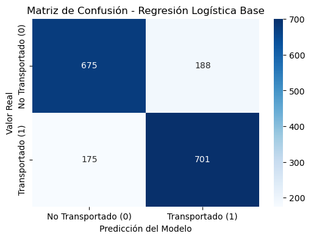

```python
# Escribe tu código aquí
# Importar el modelo y las métricas
from sklearn.linear_model import LogisticRegression
from sklearn.metrics import accuracy_score, precision_score, recall_score, f1_score, confusion_matrix
import matplotlib.pyplot as plt
import seaborn as sns

# 1. Inicializar el modelo
# - random_state=42: Asegura reproducibilidad en el algoritmo.
# - max_iter=1000: Le da suficiente tiempo al modelo para encontrar la mejor solución matemática.
modelo_logistico = LogisticRegression(random_state=42, max_iter=1000)

# 2. Entrenar el modelo con los datos de entrenamiento escalados
print("Entrenando Regresión Logística...")
modelo_logistico.fit(X_train, y_train)

# 3. Hacer predicciones sobre los datos de prueba
y_pred = modelo_logistico.predict(X_test)

# 4. Calcular métricas de evaluación
accuracy = accuracy_score(y_test, y_pred)
precision = precision_score(y_test, y_pred)
recall = recall_score(y_test, y_pred)
f1 = f1_score(y_test, y_pred)

print("\n--- Resultados del Modelo Base ---")
print(f"Exactitud (Accuracy): {accuracy:.4f}")
print(f"Precisión (Precision): {precision:.4f}")
print(f"Sensibilidad (Recall): {recall:.4f}")
print(f"Puntuación F1 (F1-Score): {f1:.4f}")

# 5. Visualizar la Matriz de Confusión
cm = confusion_matrix(y_test, y_pred)

plt.figure(figsize=(6, 4))
# Matriz de confusión
sns.heatmap(cm, annot=True, fmt='d', cmap='Blues',
            xticklabels=['No Transportado (0)', 'Transportado (1)'],
            yticklabels=['No Transportado (0)', 'Transportado (1)'])
plt.title('Matriz de Confusión - Regresión Logística Base')
plt.ylabel('Valor Real')
plt.xlabel('Predicción del Modelo')
plt.show()
```

## 4. Validación y ajuste de hiperparámetros

- Aplicar técnicas de validación cruzada (cross-validation) para medir la robustez del modelo.
- Utilizar métodos de optimización de hiperparámetros:
  - Grid Search
  - Random Search
  - Bayesian Optimization o frameworks como Optuna.
- Ajustar los parámetros que maximizan el desempeño del modelo.

```python
# Escribe tu código aquí

from sklearn.model_selection import cross_val_score, GridSearchCV
import numpy as np

# --- 1. Validación Cruzada (Cross-Validation) ---
print("Aplicando Validación Cruzada...")
# Dividimos los datos de entrenamiento en 5 partes (folds)
puntuaciones_cv = cross_val_score(modelo_logistico, X_train, y_train, cv=5, scoring='accuracy')

print(f"Exactitud en cada partición: {puntuaciones_cv}")
print(f"Exactitud Media: {puntuaciones_cv.mean():.4f}")
print(f"Desviación Estándar (menor es mejor): {puntuaciones_cv.std():.4f}")


# --- 2. Ajuste de Hiperparámetros con Grid Search ---
print("\nIniciando Grid Search para optimización de hiperparámetros...")

# Definimos el "grid" o cuadrícula de parámetros a explorar
parametros_grid = {
    'C': [0.01, 0.1, 1, 10, 100],          # Controla la fuerza de la regularización (menor = más fuerte)
    'penalty': ['l1', 'l2'],               # Tipo de penalización matemática
    'solver': ['liblinear', 'saga']        # Algoritmos de optimización compatibles con l1 y l2
}

# Configurar el GridSearchCV
grid_search = GridSearchCV(
    estimator=LogisticRegression(random_state=42, max_iter=2000),
    param_grid=parametros_grid,
    cv=5,                   # Validación cruzada de 5 particiones interna
    scoring='accuracy',     # Queremos maximizar la exactitud
    n_jobs=-1,              # Usa todos los núcleos del procesador para ir más rápido
    verbose=1               # Muestra el progreso en la consola
)

# Entrenar el Grid Search con los datos
grid_search.fit(X_train, y_train)

# Resultados del mejor modelo
print("\n--- Resultados de la Optimización ---")
print(f"Mejores Parámetros Encontrados: {grid_search.best_params_}")
print(f"Mejor Exactitud durante Validación Cruzada: {grid_search.best_score_:.4f}")

#  Modelo optimizado
mejor_modelo_logistico = grid_search.best_estimator_
```

```
Aplicando Validación Cruzada...
Exactitud en cada partición: [0.79007908 0.7922358  0.7821711  0.79295471 0.79136691]
Exactitud Media: 0.7898
Desviación Estándar (menor es mejor): 0.0039

Iniciando Grid Search para optimización de hiperparámetros...
Fitting 5 folds for each of 20 candidates, totalling 100 fits

--- Resultados de la Optimización ---
Mejores Parámetros Encontrados: {'C': 10, 'penalty': 'l1', 'solver': 'saga'}
Mejor Exactitud durante Validación Cruzada: 0.7899
```

## 5. Evaluación del modelo

- Evalúa en **X_test, y_test** con métricas adecuadas:
  - Clasificación: *accuracy*, *precision*, *recall*, *F1*, **ROC-AUC**, matriz de confusión.
  - Regresión: **MAE**, **RMSE**, **R²**.
  - Agrupamiento: **Silhouette Score**, **Davies–Bouldin**.
- Analiza **sesgo y varianza** (under/overfitting).

```
--- Evaluación Final del Modelo Optimizado (Test) ---
Exactitud (Accuracy): 0.7901
Precisión (Precision): 0.7868
Sensibilidad (Recall): 0.8002
Puntuación F1 (F1-Score): 0.7934
ROC-AUC: 0.8841

--- Análisis de Sesgo y Varianza ---
Rendimiento en Entrenamiento (Train): 0.7916
Rendimiento en Prueba (Test):         0.7901
Diferencia (Train - Test):            0.0015

Diagnóstico: BALANCE ADECUADO. El modelo generaliza bien, típico de una Regresión Logística.
```

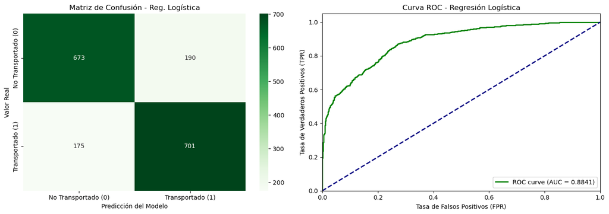

```python
from sklearn.metrics import roc_auc_score, roc_curve

# --- 1. Predicciones y Probabilidades ---
# Predicciones en Test para las métricas base
y_pred_optimizado = mejor_modelo_logistico.predict(X_test)
# Probabilidades en Test para el ROC-AUC (probabilidad de la clase 1)
y_prob_optimizado = mejor_modelo_logistico.predict_proba(X_test)[:, 1]

# Predicciones en Train para evaluar sesgo/varianza
y_pred_train_log = mejor_modelo_logistico.predict(X_train)

# --- 2. Cálculo de Métricas en Test ---
acc_log = accuracy_score(y_test, y_pred_optimizado)
prec_log = precision_score(y_test, y_pred_optimizado)
rec_log = recall_score(y_test, y_pred_optimizado)
f1_log = f1_score(y_test, y_pred_optimizado)
roc_auc_log = roc_auc_score(y_test, y_prob_optimizado)

print("--- Evaluación Final del Modelo Optimizado (Test) ---")
print(f"Exactitud (Accuracy): {acc_log:.4f}")
print(f"Precisión (Precision): {prec_log:.4f}")
print(f"Sensibilidad (Recall): {rec_log:.4f}")
print(f"Puntuación F1 (F1-Score): {f1_log:.4f}")
print(f"ROC-AUC: {roc_auc_log:.4f}\n")

# --- 3. Análisis de Sesgo y Varianza ---
acc_train_log = accuracy_score(y_train, y_pred_train_log)
diferencia_log = acc_train_log - acc_log

print("--- Análisis de Sesgo y Varianza ---")
print(f"Rendimiento en Entrenamiento (Train): {acc_train_log:.4f}")
print(f"Rendimiento en Prueba (Test):         {acc_log:.4f}")
print(f"Diferencia (Train - Test):            {diferencia_log:.4f}\n")

if diferencia_log > 0.05:
    print("Diagnóstico: OVERFITTING. El modelo se sobreajustó a los datos de entrenamiento.")
elif acc_train_log < 0.70 and acc_log < 0.70:
    print("Diagnóstico: UNDERFITTING. El modelo tiene alto sesgo, es demasiado simple.")
else:
    print("Diagnóstico: BALANCE ADECUADO. El modelo generaliza bien, típico de una Regresión Logística.")

# --- 4. Visualización: Matriz de Confusión y Curva ROC ---
fig, axes = plt.subplots(1, 2, figsize=(14, 5))

# 4.1 Matriz de Confusión (En verde, como lo tenías)
cm_optimizado = confusion_matrix(y_test, y_pred_optimizado)
sns.heatmap(cm_optimizado, annot=True, fmt='d', cmap='Greens', ax=axes[0],
            xticklabels=['No Transportado (0)', 'Transportado (1)'],
            yticklabels=['No Transportado (0)', 'Transportado (1)'])
axes[0].set_title('Matriz de Confusión - Reg. Logística')
axes[0].set_ylabel('Valor Real')
axes[0].set_xlabel('Predicción del Modelo')

# 4.2 Curva ROC
fpr_log, tpr_log, umbrales_log = roc_curve(y_test, y_prob_optimizado)
axes[1].plot(fpr_log, tpr_log, color='green', lw=2, label=f'ROC curve (AUC = {roc_auc_log:.4f})')
axes[1].plot([0, 1], [0, 1], color='navy', lw=2, linestyle='--') # Línea base
axes[1].set_xlim([0.0, 1.0])
axes[1].set_ylim([0.0, 1.05])
axes[1].set_xlabel('Tasa de Falsos Positivos (FPR)')
axes[1].set_ylabel('Tasa de Verdaderos Positivos (TPR)')
axes[1].set_title('Curva ROC - Regresión Logística')
axes[1].legend(loc="lower right")

plt.tight_layout()
plt.show()
```

## 6. Interpretación de resultados

- Analizar la importancia de las variables (feature importance).
- Visualizar errores y predicciones (por ejemplo, gráficos de dispersión o matriz de confusión).
- Evaluar si los resultados son coherentes con el contexto del problema.

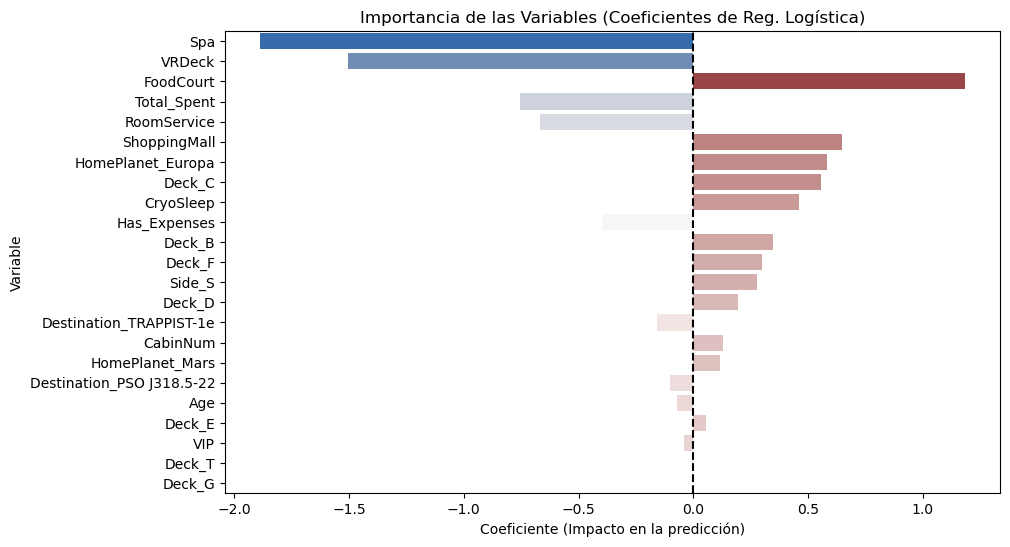

[figure not shown]

```python
# Escribe tu código aquí
# --- 1. Importancia de las Variables (Feature Importance) ---
# Extraemos los coeficientes de nuestro mejor modelo entrenado
coeficientes = mejor_modelo_logistico.coef_[0]

# Creamos un DataFrame para organizar las variables y sus coeficientes
df_importancia = pd.DataFrame({
    'Variable': X.columns,
    'Coeficiente': coeficientes
})

# Ordenamos por el valor absoluto para ver cuáles tienen mayor impacto (sea positivo o negativo)
df_importancia['Impacto_Absoluto'] = df_importancia['Coeficiente'].abs()
df_importancia = df_importancia.sort_values(by='Impacto_Absoluto', ascending=False)

plt.figure(figsize=(10, 6))
# Se usa un barplot
sns.barplot(x='Coeficiente', y='Variable', data=df_importancia, hue='Coeficiente', palette='vlag', legend=False)
plt.title('Importancia de las Variables (Coeficientes de Reg. Logística)')
plt.xlabel('Coeficiente (Impacto en la predicción)')
plt.ylabel('Variable')
plt.axvline(x=0, color='black', linestyle='--')
plt.show()

# --- 2. Análisis de Errores: Distribución de Probabilidades ---
# Obtenemos el % de seguridad (probabilidad) que tuvo el modelo para cada pasajero
probabilidades = mejor_modelo_logistico.predict_proba(X_test)[:, 1]

df_resultados = pd.DataFrame({
    'Clase_Real': y_test,
    'Probabilidad_Predicha': probabilidades
})

plt.figure(figsize=(8, 5))
# Graficamos cómo distribuye el modelo sus probabilidades dependiendo de la clase real
sns.histplot(data=df_resultados, x='Probabilidad_Predicha', hue='Clase_Real', bins=30, kde=True, palette='Set2')
plt.axvline(x=0.5, color='red', linestyle='--', label='Umbral de Decisión (0.5)')
plt.title('Distribución de Probabilidades Predichas vs Clase Real')
plt.xlabel('Probabilidad de ser Transportado (1)')
plt.ylabel('Frecuencia')
plt.legend(title='Realmente Transportado', labels=['Umbral 0.5', 'Sí (1)', 'No (0)'])
plt.show()
```

```python
# Generación dek pk para posterior despliegue

joblib.dump(mejor_modelo_logistico, 'modelo_logistico_final.pkl')

# También se guarda el scaler
joblib.dump(scaler, 'scaler.pkl')
```

```
['scaler.pkl']
```